# Single-marker CMLM GWAS using GAPIT

Haipeng Yu & Gota Morota

April 6, 2020

## Overview

This example illustrates how to fit single-marker compressed mixed linear model (CMLM) GWAS using [GAPIT](http://zzlab.net/GAPIT/). The main idea behind CMLM is to reduce computational time by constructing a genomic relationship matrix among clusters instead of individuals. In brief,

1. Use the `dist()` function to create a distance matrix from a genomic relationship matrix among individuals
2. Use the the function `hclust()` to create clusters
3. Use the function `cutree()` to assign individuals to each cluster
4. Construct a reduced genomic relationship matrix by averaging the relationships within clusters and across clusters
5. Set up the incidence matrix $\mathbf{Z}$ accordingly

## Load packages

```r
# clear working environment
rm(list=ls())

# install and load support packages
source("http://www.zzlab.net/GAPIT/GAPIT.library.R")

# load GAPIT function
source("http://www.zzlab.net/GAPIT/gapit_functions.txt")
```

## Maize data

The maize data set used here is from a [maize association panel](https://www.panzea.org/) including 281 diverse lines genotyped with 3,093 markers. The three phenotypes include ear height (EarHT), days to pollination (dpoll), and ear diameter (EarDia). In this example, we will only use EarHT.

```r
# phenotypes
myY <- read.table(file = "http://zzlab.net/GAPIT/data/mdp_traits.txt", header = TRUE)

# marker matrix
myGD <- read.table(file = "http://zzlab.net/GAPIT/data/mdp_numeric.txt", header = TRUE)

# map information of markers
myGM <- read.table(file = "http://zzlab.net/GAPIT/data/mdp_SNP_information.txt", header = TRUE)
```

## Compressed mixed linear model (CMLM) GWAS

In the `GAPIT()` function, set `model = CMLM`.

```r
# GWAS with MLM
gwasCMLMfit <- GAPIT(Y = myY[, c(1:2)], GD = myGD, GM = myGM, model = 'CMLM',
                     PCA.total = 3, SNP.P3D = TRUE, SNP.MAF = 0.05)
```

## Results

Use the `read.csv()` function to read the output file `GAPIT.CMLM.EarHT.GWAS.Results.csv`. The columns 4, 9 and 10 are p-value, FDR adjusted p-value, and marker effect, respectively.

```r
gwasCMLM <- read.csv('GAPIT.CMLM.EarHT.GWAS.Results.csv', header = TRUE)
head(gwasCMLM)
```

[output not shown]

### Manhattan plot

Open the `GAPIT.CMLM.EarHT.Manhattan.Plot.Genomewise.pdf` to view the Manhattan plot.

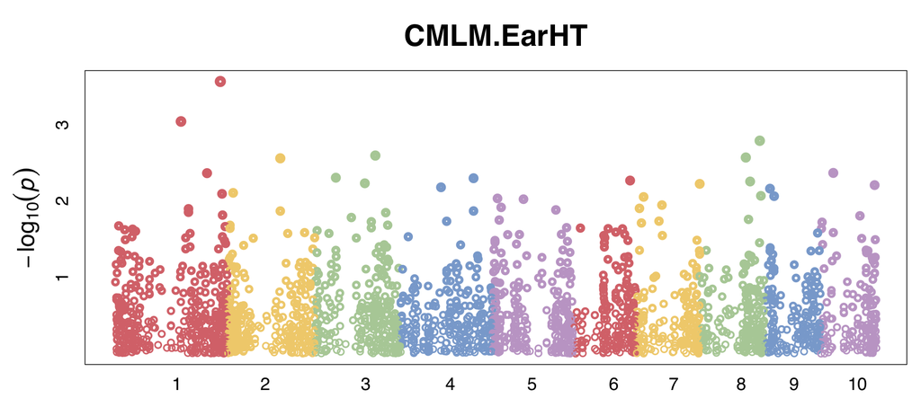

File: GAPIT.CMLM.EarHT.Manhattan.Plot.Genomewise.pdf